# piramides_2

2020-04-10

```r
eph.3.18 <- read.table("usu_individual_T318.txt",
  sep = ";", header = TRUE)
```

Y se cargan dos paquetes necesarios:

```r
library(ggplot2)
library(ggthemes)
```

## A partir de microdatos

Si se cuenta con la base de microdatos, la pirámide parte de un gráfico de barras, que cuenta la cantidades de repeticiones de cada edad. Por el modo en que se elabora la base de la EPH, es necesaria una corrección previa en la variable edad (codificada como CH06).

```r
eph.3.18$edad<-eph.3.18$CH06
eph.3.18$edad[eph.3.18$edad==-1]<-0
```

Se redefine sexo y se etiqueta:

```r
eph.3.18$sexo<-as.factor(eph.3.18$CH04)
levels(eph.3.18$sexo)<-c("varon", "mujer")
```

Se construyen dos gráficos de barras, con la variable edad tomada de cada uno de dos subconjuntos de datos: el que contiene solo mujeres y el que tiene solo varones. Por eso los datos de origen se sitúan en el `geom_bar` y no en `ggplot`. En el de varones, se multiplica por $-1$ la cuenta de casos. Luego se rotan los ejes y se indican los rótulos del eje horizontal.

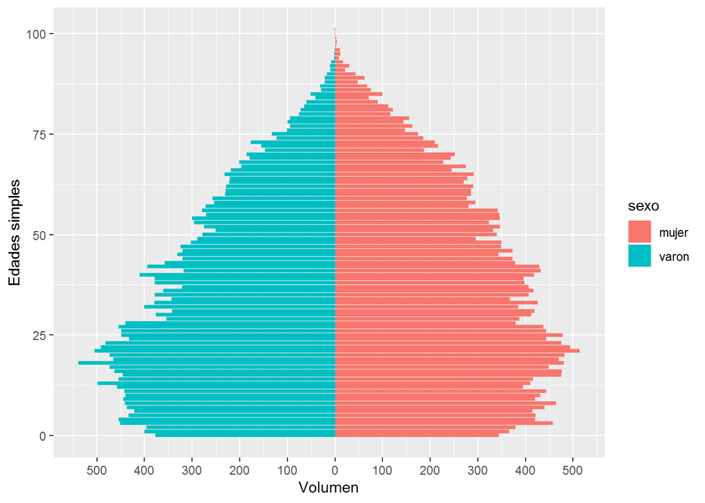

```r
ggplot()+ geom_bar(data=subset(eph.3.18, eph.3.18$sexo=="mujer"),
                   aes(edad,fill=sexo))+
  geom_bar(data=subset(eph.3.18, eph.3.18$sexo=="varon"),
                   aes(edad, fill=sexo, y=..count..*(-1)))+
  coord_flip()+
  scale_y_continuous(breaks=seq(-500,500,100),labels=abs(seq(-500,500,100)))+
  ylab("Volumen")+xlab("Edades simples")
```

### En relativos

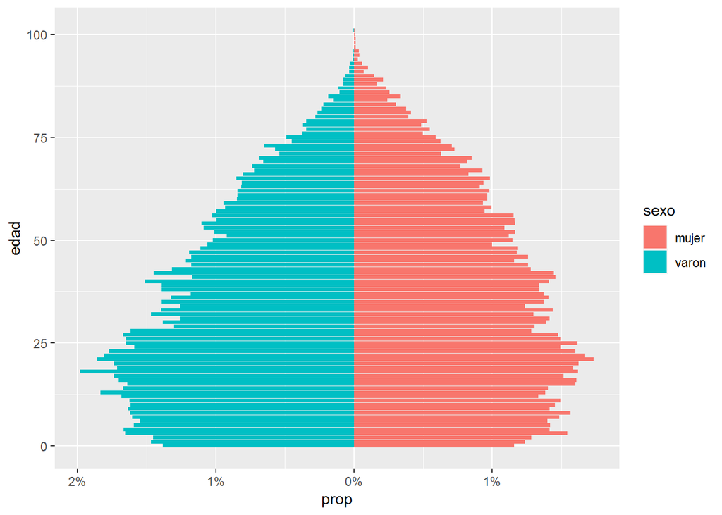

```r
ggplot()+ geom_bar(data=subset(eph.3.18, eph.3.18$sexo=="mujer"),
                   aes(edad,fill=sexo, y=..prop.., group=1))+
  geom_bar(data=subset(eph.3.18, eph.3.18$sexo=="varon"),
           aes(edad, fill=sexo, y=(..prop..)*(-1), group=1))+
  coord_flip()+
  scale_y_continuous(breaks=seq(-.02,.02,.01),
                     labels=paste0(100*abs(seq(-.02,.02,.01)),"%"))
```

## A partir de la distribución

### En absolutos

Se construye la tabla y se la trata como `data.frame`, se la etiqueta y se calcula el total de casos, para usarlo luego. A la columna *casos*, donde sexo sea varón se cambia de signo. La diferencia con lo anterior en el argumento de `geom_bar` es que hay que pedir `stat="identity"`, para que en lugar de contar ocurrencias de la categoría, tome a la columna *casos* como frecuencias.

```r
sexo_edad<-table(eph.3.18$edad, eph.3.18$sexo)
sexo_edad<-data.frame(sexo_edad)
names(sexo_edad)<-c("edad", "sexo", "casos")
n<-sum(sexo_edad$casos)

sexo_edad$casos[sexo_edad$sexo=="varon"]<--sexo_edad$casos
```

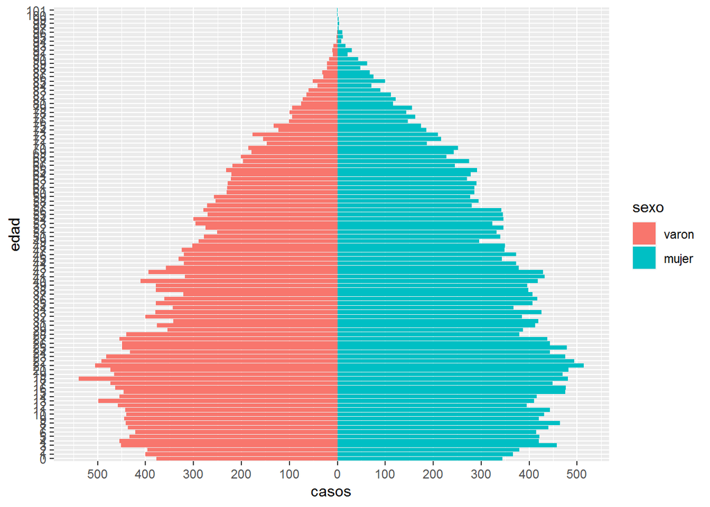

```r
ggplot(sexo_edad)+ geom_bar(aes(edad, casos,
fill=sexo), stat = "identity")+ coord_flip()+
  scale_y_continuous(breaks=seq(-500,500,100),labels=abs(seq(-500,500,100)))
```

### En relativos

La misma operación que antes, pero con una columna que se construye como los *casos* dividido el total de observaciones.

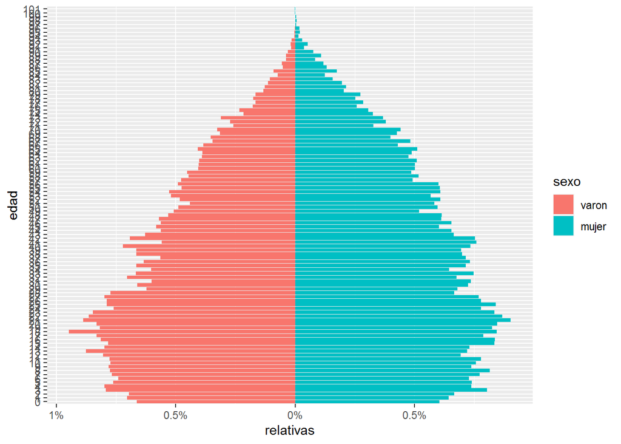

```r
sexo_edad$relativas<-sexo_edad$casos/n

ggplot(sexo_edad)+ geom_bar(aes(edad, relativas,
fill=sexo), stat = "identity")+ coord_flip()+
  scale_y_continuous(breaks=seq(-.01,.01,.005),
                     labels=paste0(100*abs(seq(-.01,.01,.005)),"%"))
```

## Categorías de edad

En la función `cut` se indican los puntos de corte y sus etiquetas, definidos primero como dos vectores. Para la categoría abierta final, elegimos un punto extremo de corte en 150 años. Por defecto los intervalos incluyen al límite superior, para evitarlo, se pide `right = FALSE`. Al final, pedimos una tabla para verificar el resultado.

```r
cortes_edad <- c(0,5,10,15,20,25,30,35,40,45,50,55,60,65,70,75,80,85,150)
clases_edad <- c("0-4","5-9","10-14","15-19","20-24","25-29","30-34",
               "35-39","40-44","45-49","50-54","55-59","60-64","65-69",
               "70-74","75-79","80-84","85+")

eph.3.18$edad_qq<-cut(eph.3.18$edad,breaks = cortes_edad,
                                right = FALSE,
                                labels = clases_edad)

table(eph.3.18$edad_qq, eph.3.18$sexo)
```

```
##
##         varon mujer
##   0-4    2078  1968
##   5-9    2178  2160
##   10-14  2294  2095
##   15-19  2387  2352
##   20-24  2385  2408
##   25-29  2147  2127
##   30-34  1841  2010
##   35-39  1819  2025
##   40-44  1801  2031
##   45-49  1567  1711
##   50-54  1400  1687
##   55-59  1333  1539
##   60-64  1133  1410
##   65-69  1028  1283
##   70-74   788  1051
##   75-79   522   785
##   80-84   314   511
##   85+     204   507
```

## Pirámide con edades agrupadas

Para hacerla desde la base de microdatos, se procede igual que antes, con la nueva variable `edad_qq`. Luego se agregan detalles de estilo.

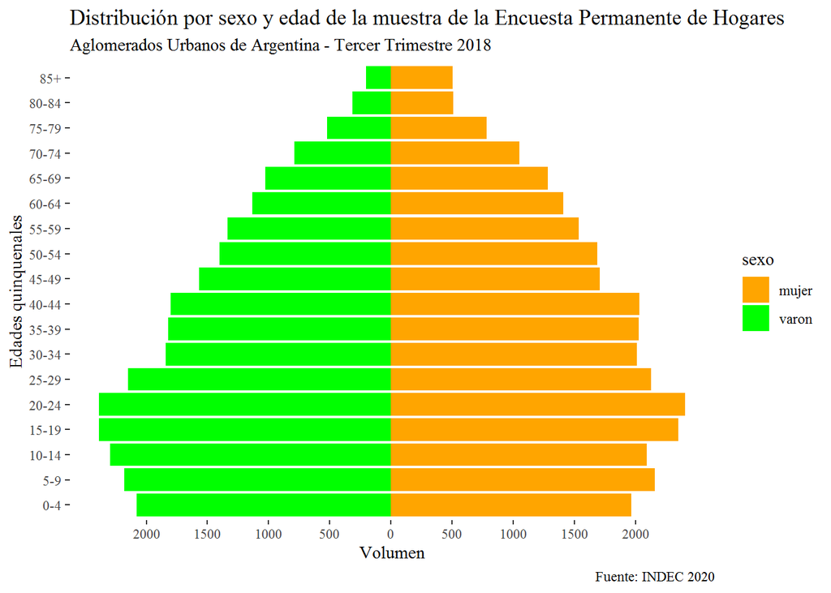

```r
ggplot()+ geom_bar(data=subset(eph.3.18, eph.3.18$sexo=="mujer"),
                   aes(edad_qq,fill=sexo))+
  geom_bar(data=subset(eph.3.18, eph.3.18$sexo=="varon"),
                   aes(edad_qq, fill=sexo, y=..count..*(-1)))+
  coord_flip()+
  scale_y_continuous(breaks=seq(-2000,2000,500),labels=abs(seq(-2000,2000,500)))+
  xlab("Edades quinquenales")+ylab("Volumen")+
  scale_fill_manual(values = c("varon"="green", "mujer"="orange"))+
  theme_tufte()+labs(title="Distribución por sexo y edad de la muestra de la Encuesta Permanente de Hogares", subtitle="Aglomerados Urbanos de Argentina - Tercer Trimestre 2018", caption="Fuente: INDEC 2020")
```

## Algunas pirámides de grupos específicos

### Estudiantes en la universidad

Se define el grupo

```r
estudiantes.3.18<-subset(eph.3.18, eph.3.18$NIVEL_ED==5 & eph.3.18$CH10==1 &
                           eph.3.18$edad<61)
```

Y se construye la pirámide para esa nueva matriz de datos

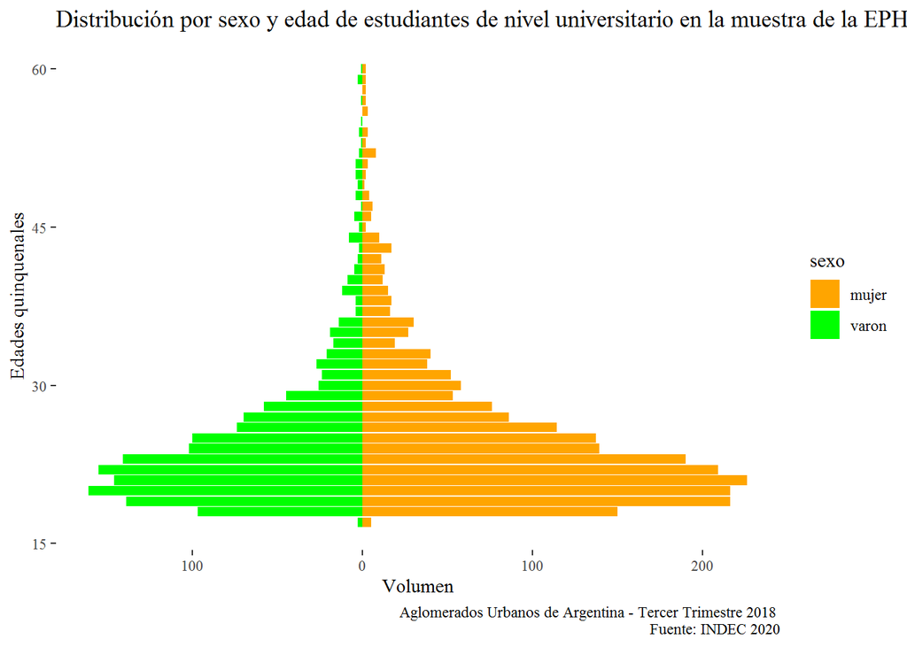

```r
ggplot()+ geom_bar(data=subset(estudiantes.3.18, estudiantes.3.18$sexo=="mujer"),
                   aes(edad,fill=sexo))+
  geom_bar(data=subset(estudiantes.3.18, estudiantes.3.18$sexo=="varon"),
                   aes(edad, fill=sexo, y=..count..*(-1)))+
  coord_flip()+
  scale_y_continuous(breaks=seq(-500,500,100),labels=abs(seq(-500,500,100)))+
  scale_x_continuous(breaks=seq(0,75, 15))+
  xlab("Edades quinquenales")+ylab("Volumen")+
  scale_fill_manual(values = c("varon"="green", "mujer"="orange"))+
  theme_tufte()+labs(title="Distribución por sexo y edad de estudiantes de nivel universitario en la muestra de la EPH", caption="Aglomerados Urbanos de Argentina - Tercer Trimestre 2018 \n Fuente: INDEC 2020")
```

### En condición de desocupación

El grupo de desocupades es:

```r
desocupades.3.18<-subset(eph.3.18, eph.3.18$ESTADO==2)
```

Y se construye la pirámide para esa nueva matriz de datos

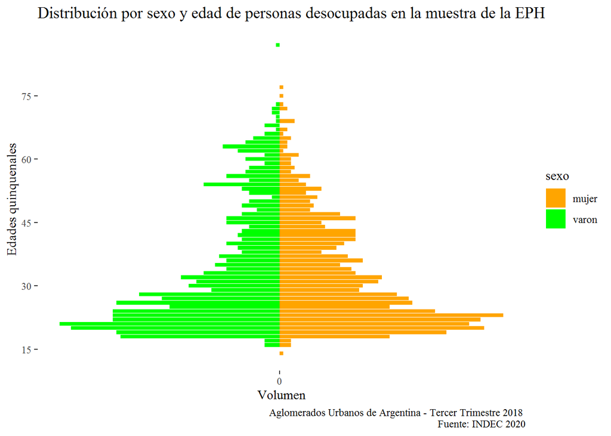

```r
ggplot()+ geom_bar(data=subset(desocupades.3.18, desocupades.3.18$sexo=="mujer"),
                   aes(edad,fill=sexo))+
  geom_bar(data=subset(desocupades.3.18, desocupades.3.18$sexo=="varon"),
                   aes(edad, fill=sexo, y=..count..*(-1)))+
  coord_flip()+
  scale_y_continuous(breaks=seq(-500,500,100),labels=abs(seq(-500,500,100)))+
  scale_x_continuous(breaks=seq(0,75, 15))+
  xlab("Edades quinquenales")+ylab("Volumen")+
  scale_fill_manual(values = c("varon"="green", "mujer"="orange"))+
  theme_tufte()+labs(title="Distribución por sexo y edad de personas desocupadas en la muestra de la EPH", caption="Aglomerados Urbanos de Argentina - Tercer Trimestre 2018 \n Fuente: INDEC 2020")
```

### Jefas y jefes de hogar

```r
jefxs.3.18<-subset(eph.3.18, eph.3.18$CH03==1)
```

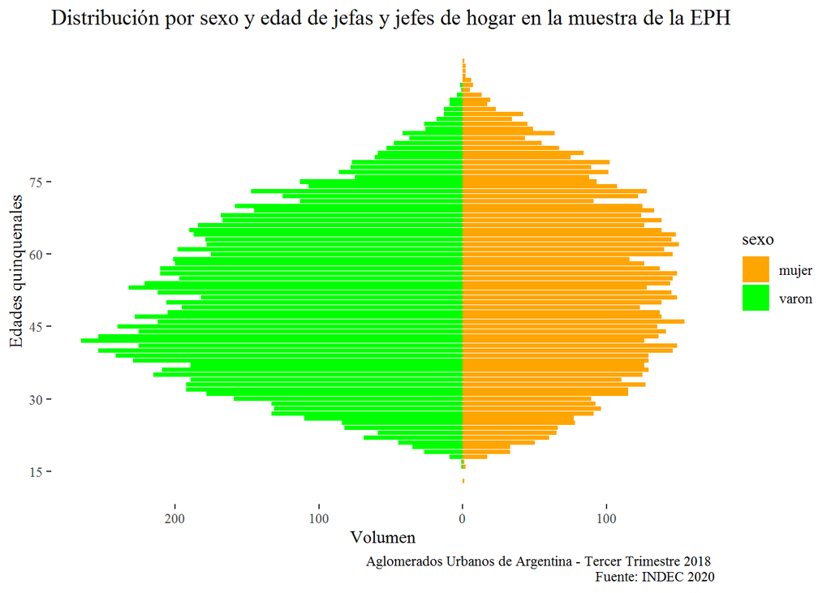

```r
ggplot()+ geom_bar(data=subset(jefxs.3.18, jefxs.3.18$sexo=="mujer"),
                   aes(edad,fill=sexo))+
  geom_bar(data=subset(jefxs.3.18, jefxs.3.18$sexo=="varon"),
                   aes(edad, fill=sexo, y=..count..*(-1)))+
  coord_flip()+
  scale_y_continuous(breaks=seq(-500,500,100),labels=abs(seq(-500,500,100)))+
  scale_x_continuous(breaks=seq(0,75, 15))+
  xlab("Edades quinquenales")+ylab("Volumen")+
  scale_fill_manual(values = c("varon"="green", "mujer"="orange"))+
  theme_tufte()+labs(title="Distribución por sexo y edad de jefas y jefes de hogar en la muestra de la EPH", caption="Aglomerados Urbanos de Argentina - Tercer Trimestre 2018 \n Fuente: INDEC 2020")
```